# 7. LepMap3: Order Markers

Lorenzo Bertola

Document last run on 2022-04-01

## 1. Background

Now that we have assigned markers to linkage groups is time to order markers within each linkage group.

## 2. Order markers

When running OrderMarkers as default, even though I do not add the sexAverage=1 option, LepMap maps all markers on both the male and the female map. I do not particularly like nor understand this, so now I run orderMarkers with male informative only (informativeMask=13) and female informative only (informativeMask=23) markers separately.

```bash
#!/bin/bash

#PBS -l ncpus=4
#PBS -l mem=15g
#PBS -l walltime=10:00:00
#PBS -J 1-195

##### Change Directory #####
cd ~/ProjectDirectory/2_LinMap

##### Get params from array #####
parameters=`sed -n "${PBS_ARRAY_INDEX} p" 0_metadata/2_4_Array`
parameterArray=($parameters)

LG_INDEX=${parameterArray[0]}
REP_INDEX=${parameterArray[1]}
out_lod=3_orderMarkers_SP/male/7_1_HC_Male_LG${LG_INDEX}_REP${REP_INDEX}_LOD
out_int=3_orderMarkers_SP/male/7_1_HC_Male_LG${LG_INDEX}_REP${REP_INDEX}_INT
output=3_orderMarkers_SP/male/7_1_HC_Male_LG${LG_INDEX}_REP${REP_INDEX}.txt

##### Run order chromosomes #####
java -cp 0_lepmap/bin/ OrderMarkers2 \
data=6_1_parcall_HC map=6_3_joinsingles_HC \
chromosome=${LG_INDEX} computeLODScores=${out_lod} calculateIntervals=${out_int} informativeMask=13 numThreads=4 > $output
```

I produced the *2_4_Array* array file with the below command. It produces a file with 195 rows and two columns, where each linkage group is replicated 15 times (first column), and those 15 replicates are denoted by the letters a to o (second column).

```bash
for i in $(seq 1 13)
do
  for j in $(seq 1 15)
  do
    echo $i
  done
done > 0_metadata/2_4_array

for i in $(seq 1 13)
do
  printf "a\nb\nc\nd\ne\nf\ng\nh\nj\nk\ni\nl\nm\nn\no\n"done > 0_metadata/temp

paste -d' ' 0_metadata/2_4_array 0_metadata/temp > 0_metadata/2_4_array

rm 0_metadata/temp
```

For each run I saved:

- a **LOD Scores** file, containing placement LOD scores of final and possible positions (more on this later)
- an **Intervals** file, containing the distance in cM between markers within each map
- a **MAP** file, containing the position, in cM, of markers within each map

## 3. Selecting the best run

```bash
#!/bin/bash
cd "./male"

for LG in {1..13} ; do
  for REP in {a..o} ; do
    echo -n "$LG ${REP} " >> "7_2_HC_male_LIK.txt"
    echo | sed '2q;d' "7_1_HC_Male_LG${LG}_REP${REP}.txt" | awk '{print $7}' >> "7_2_HC_male_LIK.txt"
  done
done

cd "./female"
for LG in {1..13} ; do
  for REP in {a..o} ; do
    echo -n "$LG ${REP} " >> "7_2_HC}_female_LIK.txt"
    echo | sed '2q;d' "7_1_HC_Female_LG${LG}_REP${REP}.txt" | awk '{print $7}' >> "7_2_HC_female_LIK.txt"
  done
done
```

```r
library(tidyverse)
library(ggpubr)
```

```r
HC_LIKm <- read_delim("../2_LinMap/7_2_HC_male_LIK.txt",
                      delim = " ",
                      col_names = c("LG","ITE","LIK"))

HC_LIKf <- read_delim("../2_LinMap/7_2_HC_female_LIK.txt",
                      delim = " ",
                      col_names = c("LG","ITE","LIK"))
```

Now, let’s plot them LG by LG for each family, to see if there’s any obvious outliers

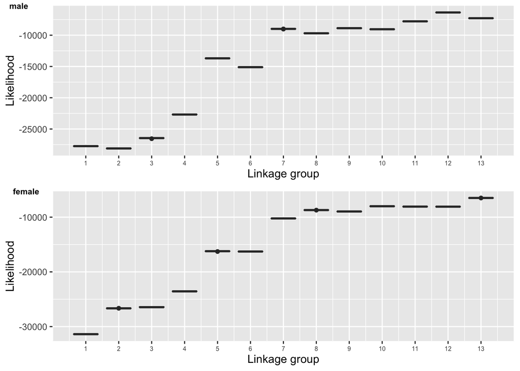

```r
p1 <- ggplot(HC_LIKm, aes(x = LG, y = LIK, group = LG)) +
  geom_boxplot() +
  scale_x_continuous(breaks = seq(1,13,1)) +
  ylab("Likelihood") + xlab("Linkage group") +
  theme(axis.text.x = element_text(size=6))


p2 <- ggplot(HC_LIKf, aes(x = LG, y = LIK, group = LG)) +
  geom_boxplot() +
  scale_x_continuous(breaks = seq(1,13,1)) +
  ylab("Likelihood") + xlab("Linkage group") +
  theme(axis.text.x = element_text(size=6))

ggarrange(p1,p2,
          ncol = 1, nrow = 2, align = "hv",
          labels = c("male","female"),
          font.label = list(size = 8))
```

The likelihood is pretty consistent across the 15 runs. Now, let’s find which iteration has the highest likelihood.

```r
HC_bestm <- HC_LIKm %>% group_by(LG) %>%
  slice_max(n=1, order_by=LIK, with_ties=FALSE) %>%
  select(LG, ITE) %>% unite("Best", remove = TRUE, sep = "_")

HC_bestf <- HC_LIKf %>% group_by(LG) %>%
  slice_max(n=1, order_by=LIK, with_ties=FALSE) %>%
  select(LG, ITE) %>% unite("Best", remove = TRUE, sep = "_")
```

```r
write_delim(HC_bestm,
            file = "../2_LinMap/7_3_HC_male_Best.txt",
            delim = "\t", col_names = FALSE)

write_delim(HC_bestf,
            file = "../2_LinMap/7_3_HC_female_Best.txt",
            delim = "\t", col_names = FALSE)
```

I do so with a for loop plus while script.

DISCLAIMER: I Left this here for others that might find they have a similar issue (e.g., wanting to move a lot of files at once based on info on another file). The directory paths are all wrong as they match the directories on my HPC home directory. They will not work for you. I just thought it might be a useful script for others wanting to extract the best runs.

```bash
#!/bin/bash
cd ../3_orderMarkers_SP/male

#loop through the four families
for FAM in FC HC KI WC ; do
#loop through rows of file containing best run info
  while read p; do
  #select LG from row
    LG=`awk -F'[_]' '{print $1}' <<< "$p"`
  #select REP id from row
    REP=`awk -F'[_]' '{print $2}' <<< "$p"`
  #copy and rename the files for the best run for each LG
    cp "7_1_${FAM}_Male_LG${LG}_REP${REP}.txt" "7_4_${FAM}_male_LG${LG}.txt"
    cp "7_1_${FAM}_Male_LG${LG}_REP${REP}_LOD" "7_4_${FAM}_male_LG${LG}_LOD"
    cp "7_1_${FAM}_Male_LG${LG}_REP${REP}_INT" "7_4_${FAM}_male_LG${LG}_INT"
  done < "7_3_${FAM}_male_Best.txt"
done

cd ../female

#loop through the four families
for FAM in FC HC KI WC ; do
#loop through rows of file containing best run info
  while read p; do
  #select LG from row
    LG=`awk -F'[_]' '{print $1}' <<< "$p"`
  #select REP id from row
    REP=`awk -F'[_]' '{print $2}' <<< "$p"`
  #copy and rename the files for the best run for each LG
    cp "7_1_${FAM}_Female_LG${LG}_REP${REP}.txt" "7_4_${FAM}_female_LG${LG}.txt"
    cp "7_1_${FAM}_Female_LG${LG}_REP${REP}_LOD" "7_4_${FAM}_female_LG${LG}_LOD"
    cp "7_1_${FAM}_Female_LG${LG}_REP${REP}_INT" "7_4_${FAM}_female_LG${LG}_INT"
  done < "7_3_${FAM}_female_Best.txt"
done
```